# R_머신러닝(2장)

Jang, Eunhee

2018년 5월 23일

# 2장

### 목차

1. 자료구조
2. R에 데이터 로드하는 방법 4가지
3. 중심경향 측정
4. 히스토그램과 막대그래프
5. 정규분포
6. 분산과 표준편차
7. 범주형 변수 살펴보기
8. 최빈값
9. 산포도
10. 이원 교차표

### 2_1. 자료구조

#### 자료구조의 종류

1. 벡터 (vector)
2. 펙터 (factor)
3. 리스트 (list)
4. 데이터 프레임 (data frame)
5. 메트릭스 (matrix)
6. 어레이 (array)

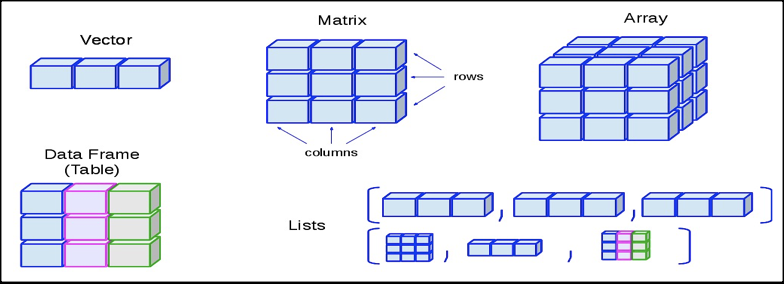

### 벡터: 같은 데이터 타입을 갖는 1차원 배열구조

1. c(): combine balue, seq(): sequence value 함수를 사용하여 vector를 만듬

#### 예제.

```r
  a <- c(1,2,3,4,5)
  a
```

```
## [1] 1 2 3 4 5
```

```r
  str(a)
```

```
##  num [1:5] 1 2 3 4 5
```

#### 문제194. 아래의 숫자들을 출력하는 vector를 생성하시오

1 2 3 4 5 6 7 8 9 10 11 12 13 14 15 16 17 18 19 20

```r
b <- c(1:20)
b
```

```
##  [1]  1  2  3  4  5  6  7  8  9 10 11 12 13 14 15 16 17 18 19 20
```

#### 문제195. 아래의 숫자들을 출력하는 vector를 생성하시오

```r
c <- c(rep(1,5),rep(2,6),rep(3,8),rep(4,6))
c
```

```
##  [1] 1 1 1 1 1 2 2 2 2 2 2 3 3 3 3 3 3 3 3 4 4 4 4 4 4
```

#### 문제196. 아래와 같은 백터를 생성하시오

x 컬럼명: scott king jones 데이터: 1 3 4

```r
# 방법1
x <- c("scott" = 1,"king" = 3,"jones" = 4)
x
```

```
## scott  king jones
##     1     3     4
```

```r
# 방법2
x <- c(1,3,4)
names(x) <- c("scott","king","jones")
x
```

```
## scott  king jones
##     1     3     4
```

#### 문제197. 문제198 x의 요소중에서 2번째것만 빼고 출력하시오

```r
x <- c(1,3,4)
names(x) <- c("scott","king","jones")
x
```

```
## scott  king jones
##     1     3     4
```

```r
x[-2]
```

```
## scott jones
##     1     4
```

```r
x[c(1,3)]
```

```
## scott jones
##     1     4
```

### 팩터: 범주를 갖는 vector ( 범주형 )

1. factor() 함수를 통해 생성
2. factor는 nominal, ordinal형식 2가지가 존재
3. nominal(명목형) 은 level의 순서의 값이 무의미하며 알파벳 순서로 정의
4. ordinal(순서형) 은 level의 순서의 값을 직접 정의해서 원하는 순서로 정의할 수 있다.

#### 예제.

```r
f1 <- c("middle","low","high")
f1
```

```
## [1] "middle" "low"    "high"
```

```r
str(f1)
```

```
##  chr [1:3] "middle" "low" "high"
```

```r
f2 <- factor(f1)
f2
```

```
## [1] middle low    high
## Levels: high low middle
```

```r
str(f2)
```

```
##  Factor w/ 3 levels "high","low","middle": 3 2 1
```

```r
# nominal

f3 <- factor(f1, order = TRUE, level = c("low","middle","high"))
f3
```

```
## [1] middle low    high
## Levels: low < middle < high
```

```r
str(f3)
```

```
##  Ord.factor w/ 3 levels "low"<"middle"<..: 2 1 3
```

```r
# ordinal
```

```r
max(f3)
```

```
## [1] high
## Levels: low < middle < high
```

```r
min(f3)
```

```
## [1] low
## Levels: low < middle < high
```

```r
max(f1)
```

```
## [1] "middle"
```

```r
min(f1)
```

```
## [1] "high"
```

```r
f3[order(f2, decreasing = T)]
```

```
## [1] middle low    high
## Levels: low < middle < high
```

### 리스트: 서로 다른 데이터 구조(vector, data frame, arry, list)의 중첩된 데이터 구조

1. list() 함수를 이용해서 데이터 구조를 중첩할 수 있다.

#### 예제.

```r
list(ename = "scott", sal = 3000)
```

```
## $ename
## [1] "scott"
##
## $sal
## [1] 3000
```

```r
list(ename = "scott", sal = c(1000,2000,3000))
```

```
## $ename
## [1] "scott"
##
## $sal
## [1] 1000 2000 3000
```

### 데이터 프레임: 각기 다른 데이터 타입을 갖는 컬럼으로 이루어진 2차원 테이블 구조

1. data.frame() 함수를 이용하여 생성하며 각 컬럼, 행의 이름을 지정할 수 있다.

#### 예제.

```r
k1 <- data.frame(x = c(1,2,3,4,5), y = c(2,3,4,6,10))
k1
```

```
##   x  y
## 1 1  2
## 2 2  3
## 3 3  4
## 4 4  6
## 5 5 10
```

#### 문제199. 위의 예제의 k1에서 0만 출력해보시오

```r
k1[5,2]
```

```
## [1] 10
```

#### 문제200. 위의 k1변수의 결과에서 x열만 출력하시오

```r
k1[1]
```

```
##   x
## 1 1
## 2 2
## 3 3
## 4 4
## 5 5
```

```r
k1[,1]
```

```
## [1] 1 2 3 4 5
```

```r
k1[,"x"]
```

```
## [1] 1 2 3 4 5
```

### matrix: 같은 데이터 타입을 갖는 2차원 배열구조

matrix() 함수를 사용해서 vector 값과 표시할 행과 열을 지정할 수 있다.

#### 예제.

```r
matrix(c(1:9), nrow = 3)
```

```
##      [,1] [,2] [,3]
## [1,]    1    4    7
## [2,]    2    5    8
## [3,]    3    6    9
```

#### 문제201. 아래와 같은 matrix를 만드시오

1 2 3 4 5 6 7 8 9

```r
matrix(c(1:9), nrow = 3, byrow = T)
```

```
##      [,1] [,2] [,3]
## [1,]    1    2    3
## [2,]    4    5    6
## [3,]    7    8    9
```

```r
matrix(c(1:9), ncol = 3, byrow = T)
```

```
##      [,1] [,2] [,3]
## [1,]    1    2    3
## [2,]    4    5    6
## [3,]    7    8    9
```

#### 문제202. 아래와 같은 matrix를 만드시오

1 2 3 4 5 6 7 8 9 10 11 12

```r
matrix(c(1:12), nrow = 3, ncol = 4, byrow = T)
```

```
##      [,1] [,2] [,3] [,4]
## [1,]    1    2    3    4
## [2,]    5    6    7    8
## [3,]    9   10   11   12
```

#### 문제203. 아래의 행렬 합을 구현하시오

1 2 3 1 4 7 4 5 6 + 2 5 8 = ? 7 8 9 3 6 9

```r
a <- matrix(c(1:9), nrow = 3, byrow = T)
b <- matrix(c(1:9), nrow = 3)
a+b
```

```
##      [,1] [,2] [,3]
## [1,]    2    6   10
## [2,]    6   10   14
## [3,]   10   14   18
```

#### 문제204. 아래의 행렬식을 구현하시오

<원소별 곱> 1 2 3 1 4 7 4 5 6 * 2 5 8 = ? 7 8 9 3 6 9

<행렬곱>

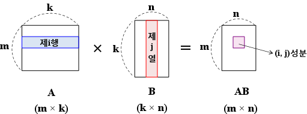

1 2 3 1 4 7 4 5 6 ◎ 2 5 8 = ? 7 8 9 3 6 9

```r
# 원소별 곱
a * b
```

```
##      [,1] [,2] [,3]
## [1,]    1    8   21
## [2,]    8   25   48
## [3,]   21   48   81
```

```r
# 행렬곱
a%*%b
```

```
##      [,1] [,2] [,3]
## [1,]   14   32   50
## [2,]   32   77  122
## [3,]   50  122  194
```

### array: 같은 다차원 배열 구조

1. matrix는 2차원 행렬이고 array는 3차원 행렬
2. array() 함수를 이용해서 3차원 배열을 생성할 수 있다.

#### 예제.

```r
# dim: 차원
array(c(1:12), dim = c(3,4))
```

```
##      [,1] [,2] [,3] [,4]
## [1,]    1    4    7   10
## [2,]    2    5    8   11
## [3,]    3    6    9   12
```

```r
array(c(1:12), dim = c(2,2,3))
```

```
## , , 1
##
##      [,1] [,2]
## [1,]    1    3
## [2,]    2    4
##
## , , 2
##
##      [,1] [,2]
## [1,]    5    7
## [2,]    6    8
##
## , , 3
##
##      [,1] [,2]
## [1,]    9   11
## [2,]   10   12
```

```r
array(c(1:12), dim = c(2,2,2,2))
```

```
## , , 1, 1
##
##      [,1] [,2]
## [1,]    1    3
## [2,]    2    4
##
## , , 2, 1
##
##      [,1] [,2]
## [1,]    5    7
## [2,]    6    8
##
## , , 1, 2
##
##      [,1] [,2]
## [1,]    9   11
## [2,]   10   12
##
## , , 2, 2
##
##      [,1] [,2]
## [1,]    1    3
## [2,]    2    4
```

### 2_2. R로 데이터를 로드하는 방법 4가지

1. csc파일 로드하는 방법

#### 예.

```r
emp <- read.csv("C:/data/emp.csv",header = T)
```

2. xlsx파일 로드하는 방법

#### 예.

```r
# install.packages("xlsx")

library(xlsx)
dept <- read.xlsx("C:/data/dept.xls",1)
# sheet 지정해주기, 1

dept
```

```
##   DEPTNO      DNAME      LOC
## 1     50        DDD NEW YORK
## 2     70         aa       bb
## 3     20   RESEARCH   DALLAS
## 4     30      SALES       AA
## 5     40 OPERATIONS   BOSTON
```

3. txt파일 로드하는 방법

#### 예.

```r
niv <- readLines("C:/data/NIV.txt")
head(niv,10)
```

```
##  [1] "Gen 1:1 In the beginning God created the heavens and the earth."
##  [2] "Gen 1:2 Now the earth was formless and empty, darkness was over the surface of the deep, and the  Spirit of God was hovering over the waters."
##  [3] "Gen 1:3 And God said, \"Let there be light,\" and there was light."
##  [4] "Gen 1:4 God saw that the light was good, and he separated the light from the darkness."
##  [5] "Gen 1:5 God called the light \"day,\" and the darkness he called \"night.\" And there was evening, and  there was morning--the first day."
##  [6] "Gen 1:6 And God said, \"Let there be an expanse between the waters to separate water from water.\""
##  [7] "Gen 1:7 So God made the expanse and separated the water under the expanse from the water above it.  And it was so."
##  [8] "Gen 1:8 God called the expanse \"sky.\" And there was evening, and there was morning--the second day."
##  [9] "Gen 1:9 And God said, \"Let the water under the sky be gathered to one place, and let dry ground  appear.\" And it was so."
## [10] "Gen 1:10 God called the dry ground \"land,\" and the gathered waters he called \"seas.\" And God saw that  it was good."
```

4. DB에서 데이터 로드하는 방법

#### 예.

```r
setwd("C:/data")
library('DBI')
library('RJDBC')

driver <- JDBC('oracle.jdbc.driver.OracleDriver','ojdbc6.jar')

oracle_db <- dbConnect(driver, 'jdbc:oracle:thin:@//127.0.0.1:1522/orcl','scott2','tiger')

emp_query <- 'select * from emp'
emp_data <- dbGetQuery(oracle_db, emp_query)
emp_data
```

```
##    EMPNO  ENAME       JOB  MGR            HIREDATE  SAL COMM DEPTNO
## 1   7839   KING PRESIDENT   NA 1981-11-17 00:00:00 5000   NA     10
## 2   7698  BLAKE   MANAGER 7839 1981-05-01 00:00:00 2850   NA     30
## 3   7782  CLARK   MANAGER 7839 1981-05-09 00:00:00 2450   NA     10
## 4   7566  JONES   MANAGER 7839 1981-04-01 00:00:00 2975   NA     20
## 5   7654 MARTIN  SALESMAN 7698 1981-09-10 00:00:00 1250 1400     30
## 6   7499  ALLEN  SALESMAN 7698 1981-02-11 00:00:00 1600  300     30
## 7   7844 TURNER  SALESMAN 7698 1981-08-21 00:00:00 1500    0     30
## 8   7900  JAMES     CLERK 7698 1981-12-11 00:00:00  950   NA     30
## 9   7521   WARD  SALESMAN 7698 1981-02-23 00:00:00 1250  500     30
## 10  7902   FORD   ANALYST 7566 1981-12-11 00:00:00 3000   NA     20
## 11  7369  SMITH     CLERK 7902 1980-12-09 00:00:00  800   NA     20
## 12  7788  SCOTT   ANALYST 7566 1982-12-22 00:00:00 3000   NA     20
## 13  7876  ADAMS     CLERK 7788 1983-01-15 00:00:00 1100   NA     20
## 14  7934 MILLER     CLERK 7782 1982-01-11 00:00:00 1300   NA     10
```

```r
sales <- 'select * from sales'
sales_data <- dbGetQuery(oracle_db, emp_query)
head(sales_data,10)
```

```
##    EMPNO  ENAME       JOB  MGR            HIREDATE  SAL COMM DEPTNO
## 1   7839   KING PRESIDENT   NA 1981-11-17 00:00:00 5000   NA     10
## 2   7698  BLAKE   MANAGER 7839 1981-05-01 00:00:00 2850   NA     30
## 3   7782  CLARK   MANAGER 7839 1981-05-09 00:00:00 2450   NA     10
## 4   7566  JONES   MANAGER 7839 1981-04-01 00:00:00 2975   NA     20
## 5   7654 MARTIN  SALESMAN 7698 1981-09-10 00:00:00 1250 1400     30
## 6   7499  ALLEN  SALESMAN 7698 1981-02-11 00:00:00 1600  300     30
## 7   7844 TURNER  SALESMAN 7698 1981-08-21 00:00:00 1500    0     30
## 8   7900  JAMES     CLERK 7698 1981-12-11 00:00:00  950   NA     30
## 9   7521   WARD  SALESMAN 7698 1981-02-23 00:00:00 1250  500     30
## 10  7902   FORD   ANALYST 7566 1981-12-11 00:00:00 3000   NA     20
```

### 데이터의 종류

1. 범주형 데이터
- 명목형(noraminal): 몇개의 범주로 나누어진 자료
- 순서형(ordinal): 명목형 데이터 + 순서
2. 수치형
- 이산형 데이터(discreat: 뚜렷이 구별되다. 불연속적이다) 즉, 1 아니면 0이다. 신호가 있거나 1, 신호가 없거나 0

  예: 2016년 음주운전 적발건수 22만 6599건 계수( 헤아려 얻는 것)
- 연속형 데이터: 연속적인 값을 갖는 데이터

  예: 신장, 체중 계량(측정해서 얻는 것)

  이산형 데이터보다 연속형 데이터가 더 얻을 수 있는 정보가 많다.

#### 연속형 데이터에 대한 기술적인 통계를 이용한 자료 요약 3가지

1. 데이터의 중심화 경향: 중앙값, 평균값, 최빈값(가장 많이 출현되는 값)
2. 데이터의 퍼짐 정도: 분산(데이터의 퍼짐정도), 표준편차(평균에 대한 오차), 범위
3. 데이터의 분포와 대칭정도: 왜도(좌우로 기울어짐의 정도), 첨도(위아래 뾰족한 정도)

### 2_3. 중심경향 측정

1. 데이터에 대한 일반적인 통계결과 확인 방법

```r
summary(emp$sal)
```

```
##    Min. 1st Qu.  Median    Mean 3rd Qu.    Max.
##     800    1250    1550    2073    2944    5000
```

중앙값과 평균값을 확인한다.

#### 문제206. 사원테이블의 월급에 대하여 box, 산포도, plot 그래프를 겹쳐서 보이게 출력하시오

```r
graphics.off()
boxplot(emp$sal)
par(new = T)
plot(emp$sal, col = 'blue')
```

[output not shown]

#### 문제207. emp 테이블의 월급을 사분위수 그래프로 그리는데 옆으로 눕혀서 출력하고 histogram 그래프로 그리시오

```r
graphics.off()
hist(emp$sal, col = 'blue')
par(new = T)
boxplot(emp$sal, horizontal = T)
```

[output not shown]

### 2_4. 막대그래프와 히스토그램 그래프

1. 막대그래프: 데이터 안의 특정 항목들의 수량이 많고 적음을 나타낼 때 용이

#### 예제.

```r
table(emp$sal)
```

```
##
##  800  950 1100 1250 1300 1500 1600 2450 2850 2975 3000 5000
##    1    1    1    2    1    1    1    1    1    1    2    1
```

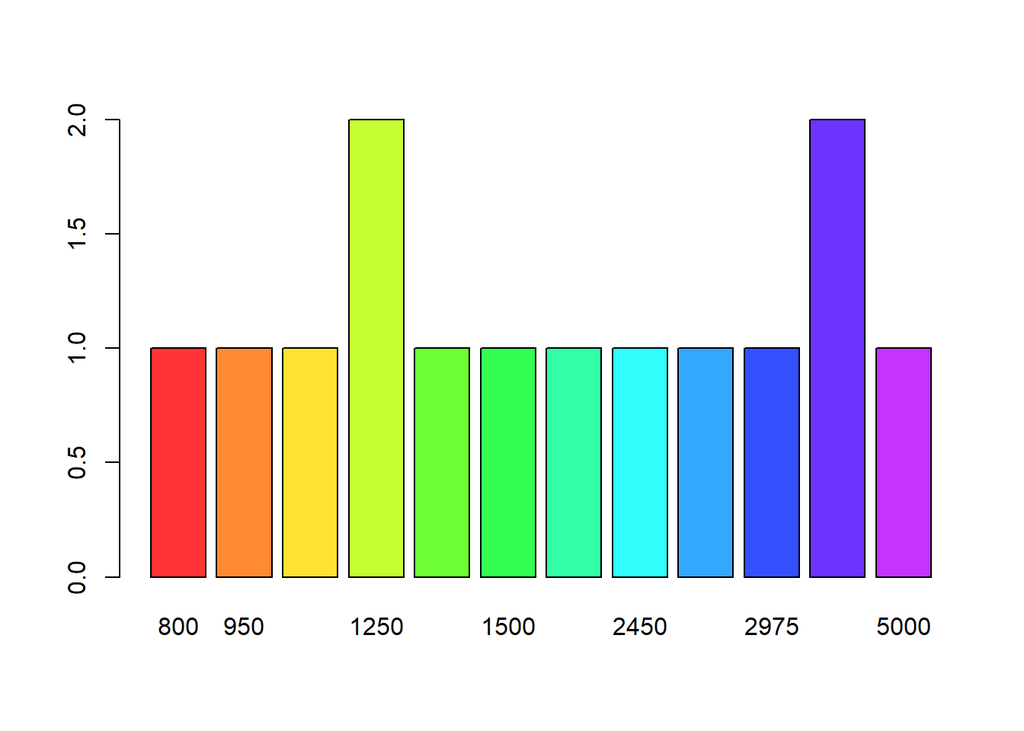

```r
barplot(table(emp$sal), col = rainbow(14, alpha = 0.8))
```

> 위의 데이터는 히스토그램 그래프가 시각화에 더 유용하다

2. 히스토그램 그래프: 데이터 안 데이터의 분포의 상태를 파악하거나 비교할 때 용이하다.

#### 예제.

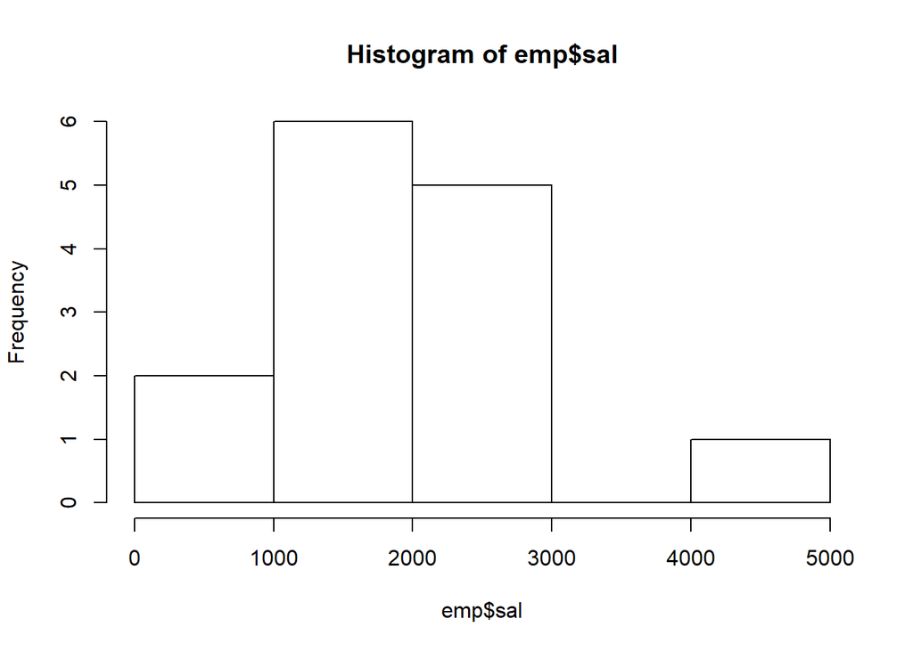

```r
hist(emp$sal)
```

#### 문제213. 우리반 나이데이터를 가지고 막대그래프와 히스토그램 그래프를 그려보시오

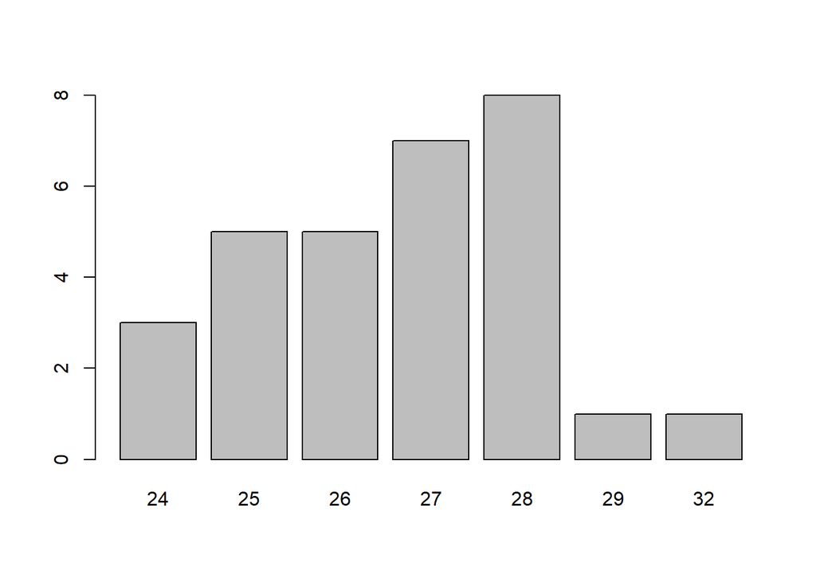

```r
emp2 <- read.csv("C:/data/emp2.csv")
barplot(table(emp2$age))
```

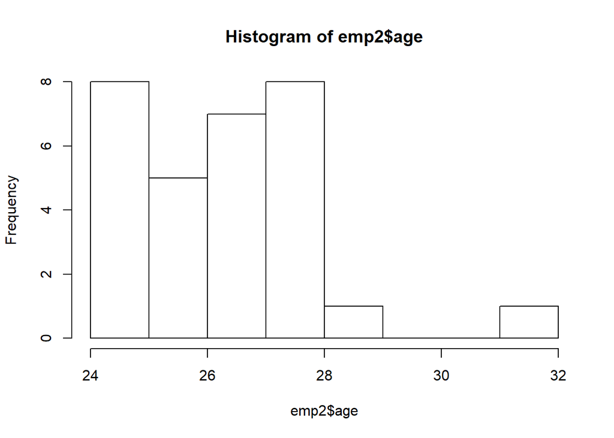

```r
# emp2$age
# table(emp2$age)
hist(emp2$age)
```

### 2_5. 정규분포: 많은 경영, 경제, 사회현상, 자연현상들이 정규분포의 형태를 띄고 있다.

#### 예를 들면 한국 성인 남자의 평균 키가 173cm이라고 하면 평균 키가 173cm라는 것은, 곧 키가 평균 173cm에서 크게 벗어나지 않은 사람들이 많고 상대적으로 벗어난 150cm, 190cm인 사람들이 별로 없다는 소리다.

#### 평균에서 멀어질수록 데이터 분포가 감소하여 종모양의 형태를 띄며 정규분포 그래프를 3등분하면 평균 근처의 비율이 68%정도 된다.

#### 문제208. 정규분포 그래프를 그리시오

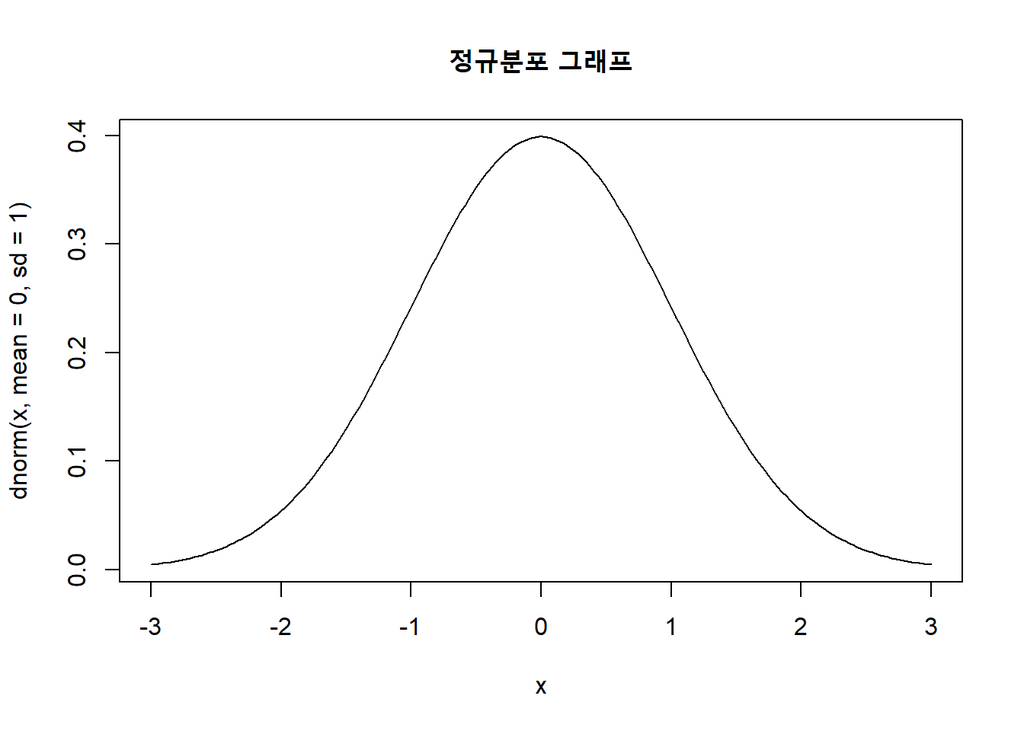

```r
# 1. -3 ~ 3까지의 데이터 200개를 만든다.
x <- seq(-3,3, length = 200)
# 2. plot 그래츠를 그린다.
plot(x, dnorm(x, mean=0, sd= 1), type = "l", main = "정규분포 그래프")
```

```r
# y축: dnorm(밀도함수), 평균 0, 표준편차 1// type = l: 직선
```

#### 문제209. emp 테이블의 월급을 정규분포 그래프로 그리시오

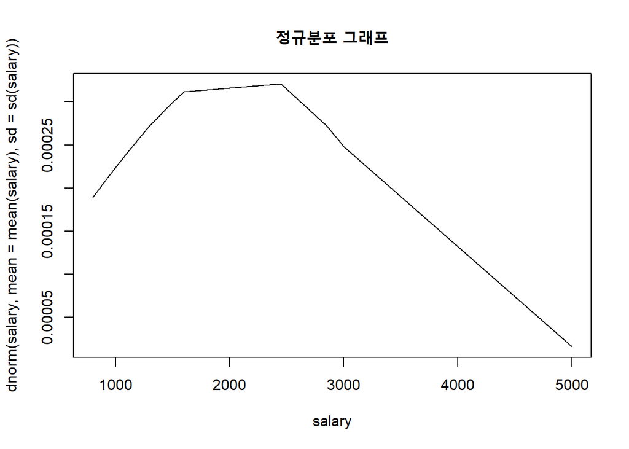

```r
salary <- emp[order(emp$sal, decreasing = F), "sal"]
plot(salary, dnorm(salary, mean=mean(salary), sd = sd(salary)), type = "l", main = "정규분포 그래프")
```

### 왜도와 첨도

##### 왜도: 데이터의 좌우로 기울어짐의 정도(skewness)

```
  왜도값 > 0 : 오른쪽 꼬리가 길다
  왜도값 < 0 : 왼쪽 꼬리가 길다.
```

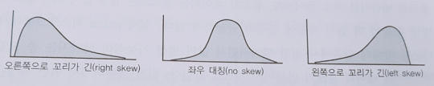

#### 문제219. 아래의 데이터의 정규분포 곡선을 그리시오

값 1 2 3 5 6 7 8 9 도수 4 6 4 4 3 2 1 1

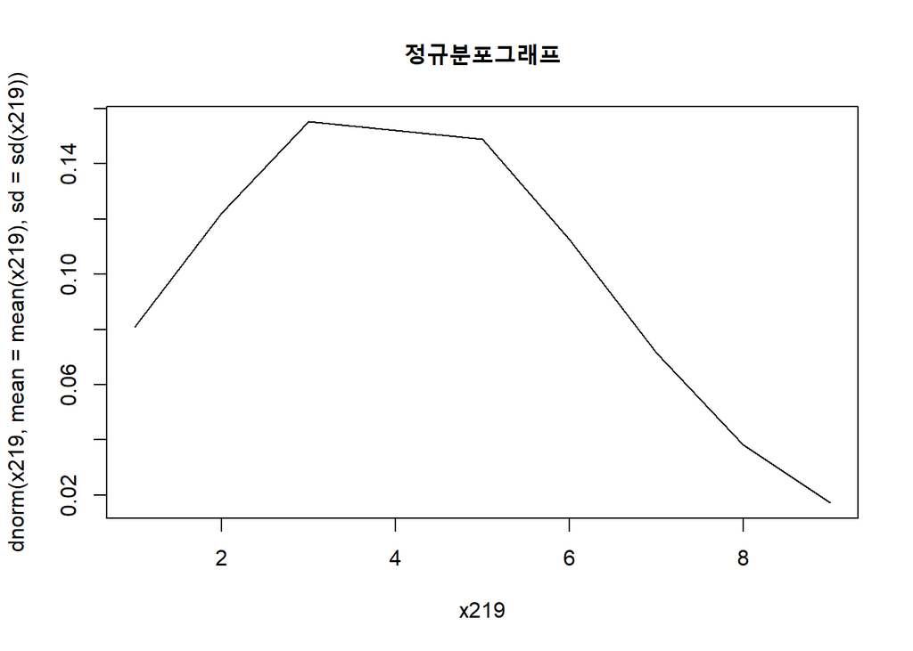

```r
x219 <- c(rep(c(1, 2, 3, 5, 6, 7, 8, 9), c( 4, 6, 4, 4, 3, 2, 1, 1)))
plot(x219, dnorm(x219, mean = mean(x219), sd = sd(x219)),type = 'l', main = "정규분포그래프")
```

#### 문제220. x219 데이터의 왜도값을 출력하시오

```r
# install.packages("fBasics")
library(fBasics)
skewness(x219)
```

```
## [1] 0.4637081
## attr(,"method")
## [1] "moment"
```

> right skew: 오른쪽으로 꼬리가 긴 그래프로 데이터들이 대부분 값이 작은쪽에 있다.

#### 문제221. 사원 테이블의 월급의 왜도값을 출력하시오!

```r
skewness(emp$sal)
```

```
## [1] 0.9349611
## attr(,"method")
## [1] "moment"
```

#### 문제222. 아래의 데이터를 만들고 정규분포곡선을 그리시오

```r
x222 <- c( rep(c(1:8),c(1,1,2,3,4,4,6,4)))

table(x222)
```

```
## x222
## 1 2 3 4 5 6 7 8
## 1 1 2 3 4 4 6 4
```

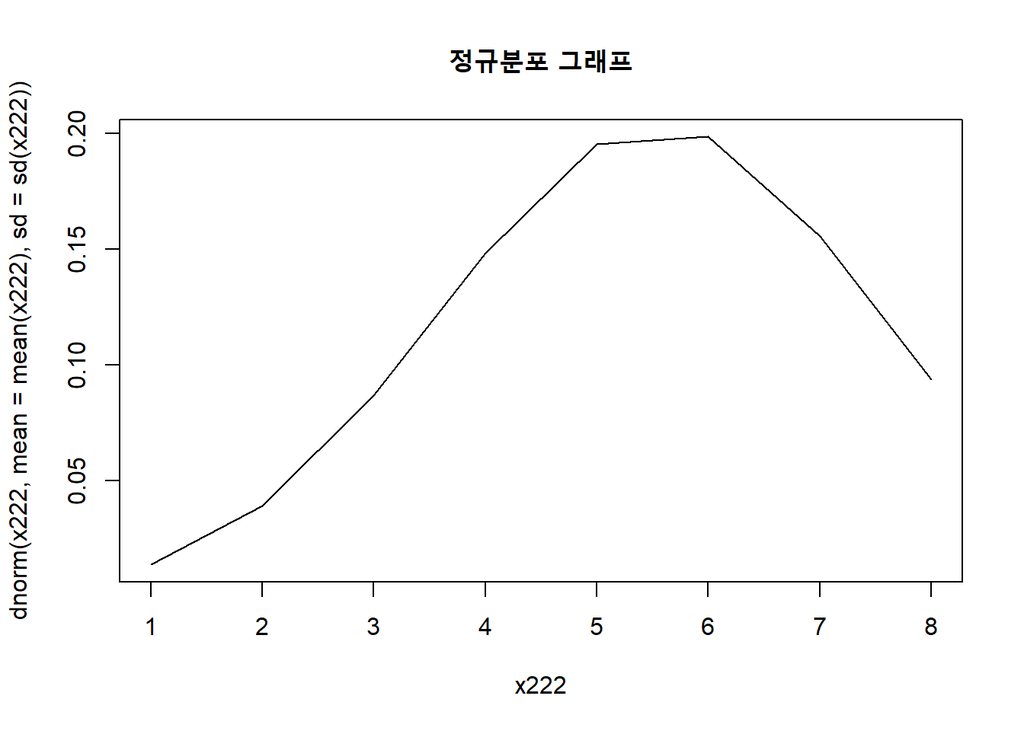

```r
plot(x222, dnorm(x222, mean = mean(x222), sd = sd(x222)), type = "l", main = "정규분포 그래프")
```

#### 문제223. x222의 왜도값을 출력하시오

```r
skewness(x222)
```

```
## [1] -0.5805801
## attr(,"method")
## [1] "moment"
```

#### 문제224. x222의 정규분포 그래프에 박스 그래프가 겹쳐서 나오게 시각화 하시오(눕혀서)

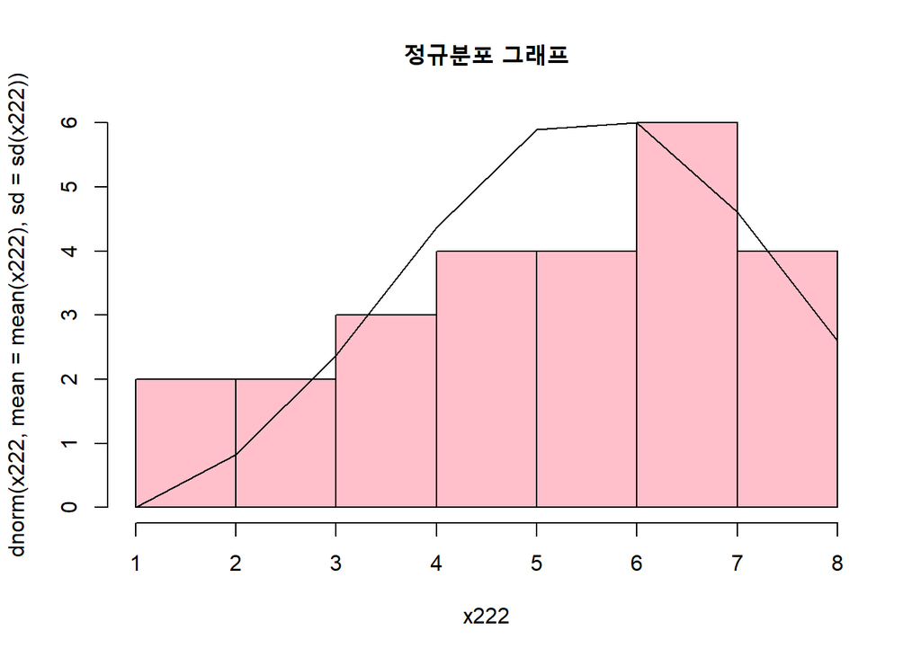

```r
hist(x222, col = "Pink",ann = FALSE)
par(new = T)
plot(x222, dnorm(x222, mean = mean(x222), sd = sd(x222)), type = "l", main = "정규분포 그래프", , axes = FALSE)
```

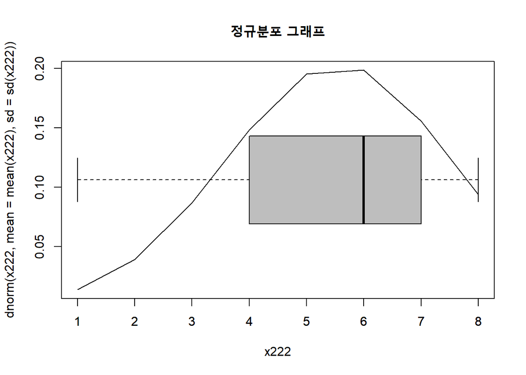

```r
plot(x222, dnorm(x222, mean = mean(x222), sd = sd(x222)), type = "l", main = "정규분포 그래프")
par(new = T)
boxplot(x222, horizontal = T, col = "grey")
```

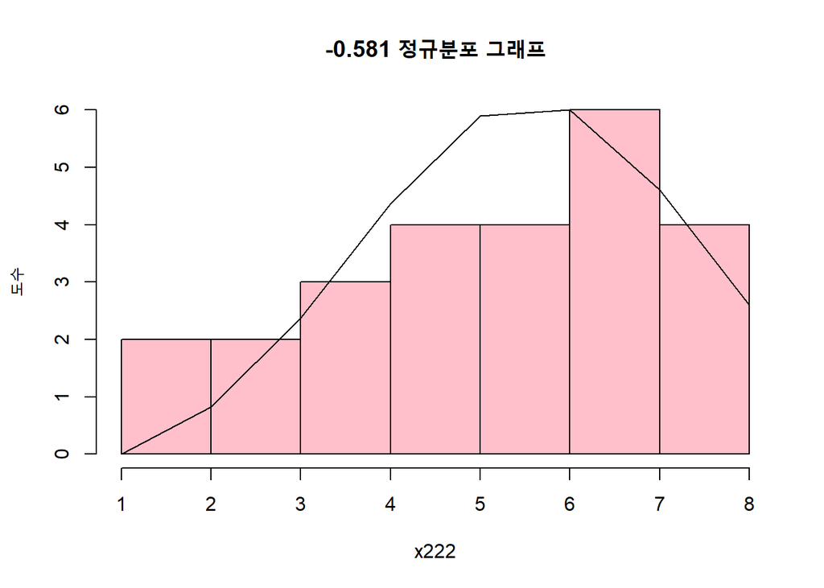

```r
hist(x222, col = "Pink",ann = FALSE)
par(new = T)
plot(x222, dnorm(x222, mean = mean(x222), sd = sd(x222)), type = "l", main = paste(round(skewness(x222),3),"정규분포 그래프"),ylab = "도수" , axes = FALSE)
```

##### 첨도: 위아래 뾰족한 정도(kurtosis)

```
  첨도값이 3에 가까울수록 정규분포에 해당하고
           3보다 작은 경우는 완만한 곡선
           3보다 크면 뾰족한 곡선
```

#### 문제227. x222의 첨도값을 확인하시오

```r
library(fBasics)
kurtosis(x222)
```

```
## [1] -0.6541229
## attr(,"method")
## [1] "excess"
```

#### 문제228. 히스토그램 그래프와 정규분포 그래프와 제목으로 왜도값을 출력하는 함수를 생성하시오

```r
norm_plot_hist <- function(){
  table <- get(readline(prompt = "정규분포 곡선을 그릴 테이블 명을 입력하세요 "))
  col <- menu(colnames(table), title = "정규분포곡선을 그릴 컬럼명을 입력하세요 ")

  col <- table[order(table[col], decreasing = F), col]

  hist(col, col = topo.colors(8, alpha=0.7),ann = FALSE)
  par(new = T)
  plot(col, dnorm(col, mean = mean(col), sd = sd(col)), type = "l",
       main = paste(round(skewness(col),3),"정규분포 그래프"),ylab = "도수" , axes = FALSE, col = "Dim Gray")
}
```

#### 문제229. emp 테이블의 월급에서 정규분포내의 평균근처의 68%에 해당하는 월급이 얼마부터 얼마인지 출력하시오

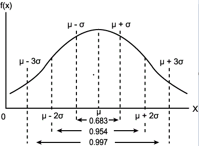

##### 필요한 data

1. emp 테이블 월급의 평균값: mean(emp$sal)
2. emp 테이블 월급의 표준편차: sd(emp$sal)

```r
mean(emp$sal)
```

```
## [1] 2073.214
```

```r
sd(emp$sal)
```

```
## [1] 1182.503
```

```r
mean(emp$sal) + sd(emp$sal)
```

```
## [1] 3255.718
```

```r
mean(emp$sal) - sd(emp$sal)
```

```
## [1] 890.7111
```

```r
# 3255는 평균값 2073과 표준편차 1182의 84%에 해당하는 데이터이다.
upper <- pnorm(mean(emp$sal) + sd(emp$sal),mean(emp$sal),sd(emp$sal))

# 891은 평균값 2073과 표준편차 1182의 15%에 해당하는 데이터이다.
lower <- pnorm(mean(emp$sal) - sd(emp$sal),mean(emp$sal), sd(emp$sal))

round(upper - lower,2)
```

```
## [1] 0.68
```

> The Normal Distribution dnorm(x, mean = 0, sd = 1, log = FALSE) pnorm(q, mean = 0, sd = 1, lower.tail = TRUE, log.p = FALSE) qnorm(p, mean = 0, sd = 1, lower.tail = TRUE, log.p = FALSE) # 등분으로 나눔 rnorm(n, mean = 0, sd = 1)

#### 문제230. 우리반 나이의 정규분포 68%에 해당하는 나이를 알아보시오

```r
mean(emp2$age)
```

```
## [1] 26.7
```

```r
sd(emp2$age)
```

```
## [1] 1.725069
```

```r
mean(emp2$age) + sd(emp2$age)
```

```
## [1] 28.42507
```

```r
mean(emp2$age) - sd(emp2$age)
```

```
## [1] 24.97493
```

```r
print(paste("나이범위:", round(mean(emp2$age) - sd(emp2$age)), "~", round(mean(emp2$age) + sd(emp2$age))))
```

```
## [1] "나이범위: 25 ~ 28"
```

```r
# 범위 확인
# upper <- pnorm(mean(emp2$age) + sd(emp2$age),mean(emp2$age),sd(emp2$age))
# # 28.42507는 평균값 0.8413447과 표준편차 1.725069의 0.8413447에 해당하는 데이터이다.
#
# lower <- pnorm(mean(emp2$age) - sd(emp2$age),mean(emp2$age), sd(emp2$age))

# round(upper - lower,2)
```

```r
used_car <- read.csv("C:/data/usedcars.csv")
str(used_car)
```

```
## 'data.frame':    150 obs. of  6 variables:
##  $ year        : int  2011 2011 2011 2011 2012 2010 2011 2010 2011 2010 ...
##  $ model       : Factor w/ 3 levels "SE","SEL","SES": 2 2 2 2 1 2 2 2 3 3 ...
##  $ price       : int  21992 20995 19995 17809 17500 17495 17000 16995 16995 16995 ...
##  $ mileage     : int  7413 10926 7351 11613 8367 25125 27393 21026 32655 36116 ...
##  $ color       : Factor w/ 9 levels "Black","Blue",..: 9 4 7 4 8 7 2 7 7 7 ...
##  $ transmission: Factor w/ 2 levels "AUTO","MANUAL": 1 1 1 1 1 1 1 1 1 1 ...
```

```r
head(used_car)
```

```
##   year model price mileage  color transmission
## 1 2011   SEL 21992    7413 Yellow         AUTO
## 2 2011   SEL 20995   10926   Gray         AUTO
## 3 2011   SEL 19995    7351 Silver         AUTO
## 4 2011   SEL 17809   11613   Gray         AUTO
## 5 2012    SE 17500    8367  White         AUTO
## 6 2010   SEL 17495   25125 Silver         AUTO
```

```r
mean(used_car$price)
```

```
## [1] 12961.93
```

```r
sd(used_car$price)
```

```
## [1] 3122.482
```

```r
mean(used_car$price) - sd(used_car$price)
```

```
## [1] 9839.452
```

```r
mean(used_car$price) + sd(used_car$price)
```

```
## [1] 16084.42
```

```r
# norm_plot_hist()
```

### 범주형 데이터 살펴보기

##### 범주형 데이터를 살펴보는 2가지 방법

1. table 함수
2. prop.table함숨

#### 예제.

```r
# Freq가 보임!
table(emp$deptno)
```

```
##
## 10 20 30
##  3  5  6
```

```r
# 비율이 보임
round(prop.table(table(emp$deptno)) * 100, digits = 1)
```

```
##
##   10   20   30
## 21.4 35.7 42.9
```

#### 문제232. 중고차의 색깔과 색깔별 비율이 어떻게 되는지 출력하시오

```r
round(prop.table(table(used_car$color)) * 100 ,1)
```

```
##
##  Black   Blue   Gold   Gray  Green    Red Silver  White Yellow
##   23.3   11.3    0.7   10.7    3.3   16.7   21.3   10.7    2.0
```

> 검정색이 전체 차 중에 23%로 가장 많은 비율을 차지하고 있다.

### 2_6. 분산과 표준편차

##### 분산: 데이터의 퍼짐정도

##### 표준편차: 평균에 대한 오차

#### - 왜 분산과 표준편차를 알아야하는가?

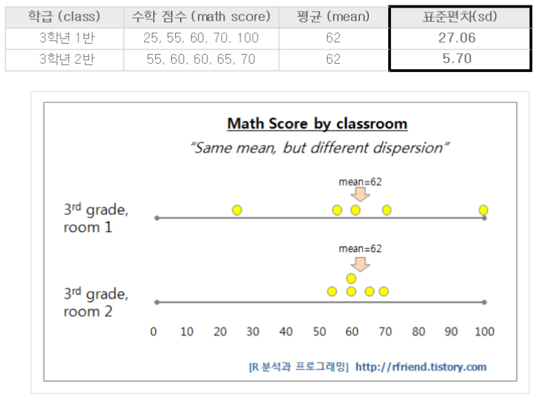

> 실제 데이터 값이 평균을 기준으로 얼마나 들쭉날쭉하느냐를 나타낸 것이 표준편차이다.

#### 편차란? 원래의 값에서 평균을 뺀것인데 편차는 +가 될 수도 있고 -가 될 수도 있다.

##### 예를들어 4개의 데이터가 있을 때 평균을 m이라고 가정하고, 각 값이 m+1,m-2,m+3,m-4라고 할 대

편차의 합은 실제로 1 + 2 + 3 + 4 = 10이어야하지만 실제값이 -2, -4이기 때문에 계산해보면 어뚱한 값인 -2가 된다.

그래서 이 음수를 향수화 해야하는데 그러한 방법 중에 하나가 제곱이다. 편차를 합하기전에 제곱해서 합한다.

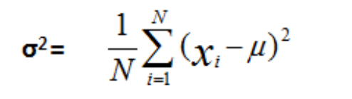

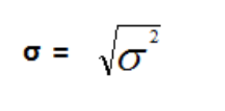

##### 분산을 바로 쓰지 않고 표준편차를 쓰는 이유?

분산을 편차에 제곱하여 계산을 하였기 때문에 실제 값과 너무 멀어져 있다. 그래서 실제값으로 근접하기 위해서 분산에 루트를 씌워준게 표준편차이다.

#### 문제213. 아래의 수학점수를 갖고 있는 두개의 학급을 각각 x1, x2로 만들고 분산과 표준편차를 각각 구하시오

```r
x1 <- c(25,55,60,70,100)
x2 <- c(55,60,60,65,70)

library(data.table)
x <- data.table(분산 = var(x1), 표준편차 = sd(x1))
y <- data.table(분산 = var(x2), 표준편차 = sd(x2))
x
```

```
##     분산 표준편차
## 1: 732.5 27.06474
```

```r
y
```

```
##    분산 표준편차
## 1: 32.5 5.700877
```

#### 문제214. 산포도 그래프를 이용해서 두 클래스의 데이터를 시각화 하시오

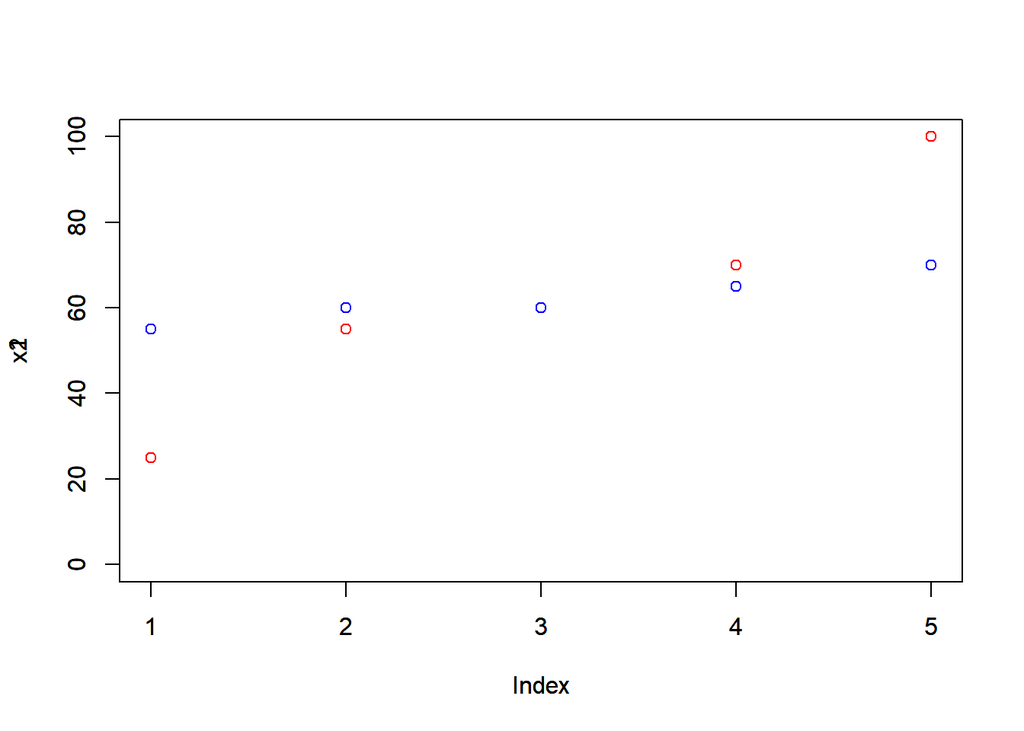

```r
x1 <- c(25,55,60,70,100)
x2 <- c(55,60,60,65,70)

plot(x1, col = "red", ylim = c(0,100))
par(new = T)
plot(x2, col = "blue", ylim = c(0,100))
```

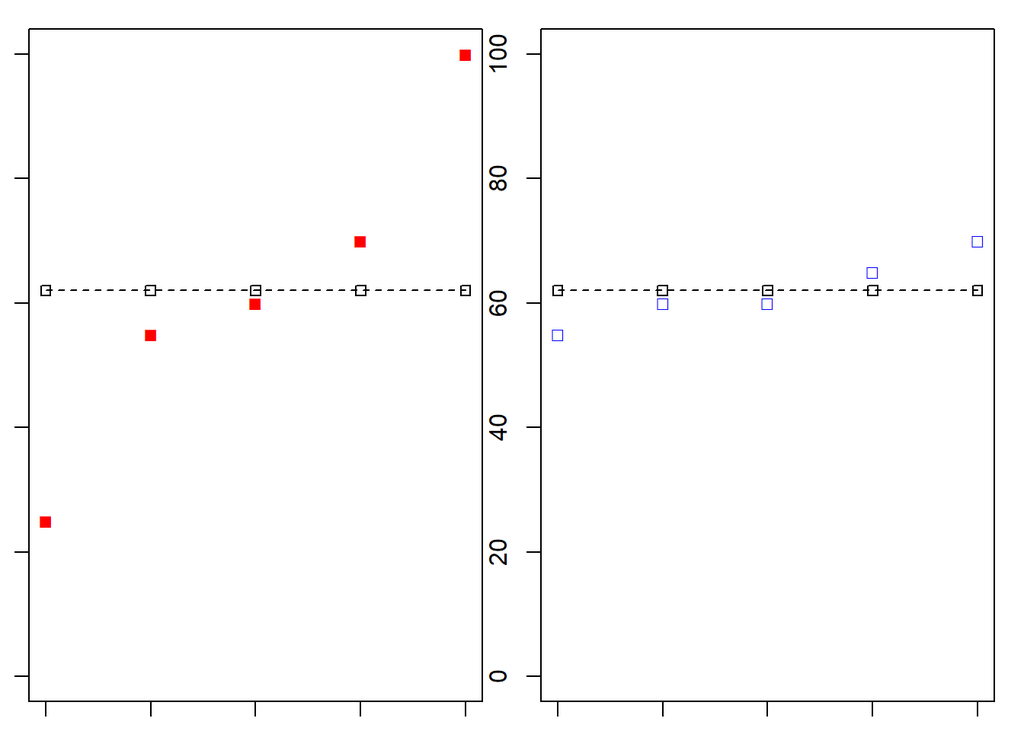

```r
x1_mean <- rep(mean(x1), 5)
x2_mean <- rep(mean(x2), 5)

# 방법1
par(mfrow = c(1,2))
par(mar = c(1,1,1,1))
# 2,1 :위아래, 1,2: 좌우

plot(x1, ylim = c(0,100), col = "red",pch = "■")
lines(x1_mean, type = "o", pch = 22, lty=2)

plot(x2, ylim = c(0,100), col = "blue", pch = "□")
lines(x2_mean, type = "o", pch = 22, lty=2)
```

```r
# 방법2
graphics.off()

plot(x1, ylim = c(0,100), col = "red",pch = "■")
lines(x1_mean, type = "o", pch = 22, lty=2)

par(new = T)

plot(x2, ylim = c(0,100), col = "blue", pch = "□")
lines(x2_mean, type = "o", pch = 22, lty=2)
```

#### 문제215. 7기의 나이와 6기 나이의 분산과 표준편차를 각각 구하고 시각화 하시오

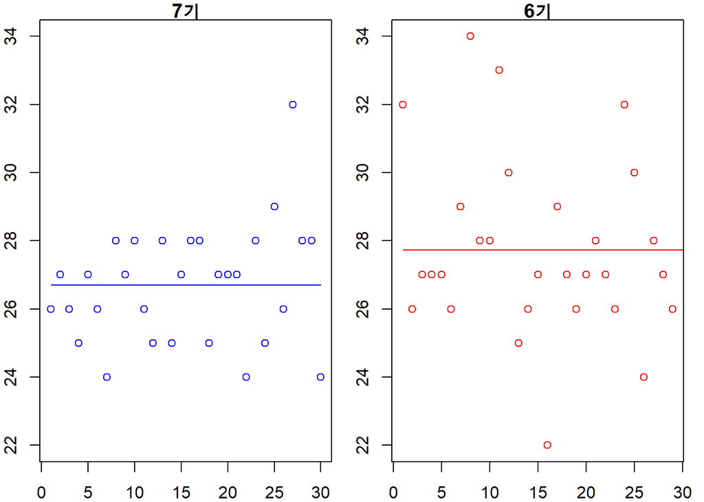

```r
x7 <- emp2$age
a7 <- var(x7)
b7 <- sd(x7)

emp6 <- read.csv("C:/data/emp99.csv")
x6 <- emp6$age
a6 <- var(x6)
b6 <- sd(x6)

par(mfrow = c(1,2))
par(mar = c(2,2,1,1))

plot(x7, col = "blue", ylim = c(22,34), main = "7기")
lines(rep(mean(x7),30), type = "l", col = "blue")

plot(x6, col = "red", ylim = c(22,34), main = "6기")
lines(rep(mean(x6),30), type = "l", col = "red")
```

#### 문제216. 분산과 표준편차를 제목으로 두고 데이터의 분산을시각화하는 함수를 생성하시오

```r
data_var_sd <- function(){
  table <- get(readline(prompt = "분산을 시각화할 테이블명을 입력하시오 "))
  col <- menu(colnames(table), title = '분산을 시각화할 컬럼을 선택하세요.')
  x <- table[,col]
  cnt <- length(x)
  plot( x, main = paste("분산 =", round(var(x),3), "표준편차 =", round(sd(x),3)),
        col = "Navy Blue",ylab = colnames(table[col]))
  lines(rep(mean(x),cnt), type = "l", col = "Violet Red")
}
```

#### 문제217. emp 테이블의 월급의 범위를 구하시오

```r
range(emp$sal)
```

```
## [1]  800 5000
```

#### 문제218. 위에서 출력한 두 값의 차이를 구하시오

```r
max(emp$sal) - min(emp$sal)
```

```
## [1] 4200
```

```r
max(range(emp$sal)) - min(range(emp$sal))
```

```
## [1] 4200
```

```r
range(emp$sal)[2] - range(emp$sal)[1]
```

```
## [1] 4200
```

### 2_8. 최빈값이란?

#### 가장 빈번히 발생하는 값, 출현 빈도가 높은 데이터

#### 예제. 17살인 A가 10대를 위한 수영교술에 수강하려 한다. 해당 수영교실에 평균 나이를 확인해서 A가 들어가도 되는 교실인지 확인해보려고 한다.

#### 아래의 데이터를 만들고 아래의 데이터의 나이의 평균을 출력하시오

나이 1 2 3 31 32 33 도수 3 4 2 2 4 3

```r
# 방법1.
age <- c(rep(1,3), rep(2,4),rep(3,2), rep(31,2), rep(32,4), rep(33,3))
mean(age)
```

```
## [1] 17
```

```r
# 방법2.
age2 <- c(rep(c(1,  2,  3,  31,  32,  33),c(3,  4,  2,  2,   4,   3)))
summary(age2)
```

```
##    Min. 1st Qu.  Median    Mean 3rd Qu.    Max.
##       1       2      17      17      32      33
```

> 알고보니 엄마와 아기가 함께하는 수영교실 그래서 평균값만 알아서는 안된다. 최빈값을 알아야한다.

#### 문제211. 위의 데이터 age의 최빈값을 구하시오

```r
y <- table(age)
y <- data.frame(y)
y[y$Freq == max(y$Freq),]
```

```
##   age Freq
## 2   2    4
## 5  32    4
```

> 최빈값은 빈번히 출현하는 데이터로 데이터안에 존재하는 값이다.

#### 문제212. 우리반의 나이 중에 최빈값을 구하시오

```r
emp2 <- read.csv("C:/data/emp2.csv", header = T)

emp2 <- table(emp2$age)
# 원하는 컬럼만 넣어서 table을 생성하면 Freq이 생심
emp2 <- data.frame(emp2)
emp2[emp2$Freq == max(emp2$Freq),]
```

```
##   Var1 Freq
## 5   28    8
```

### 2_9.산포도 그래프

#### 문제233. 커미션을 받는 사원들의 월급의 분포가 어떻게 되는지 산포도 그래프로 확인하시오

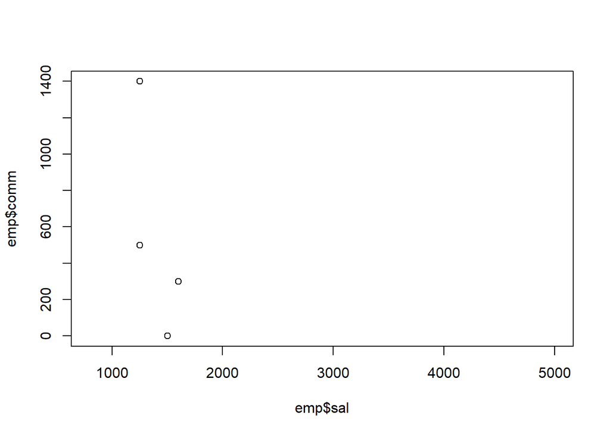

```r
# plot(x,y)

plot(emp$sal, emp$comm)
```

#### 문제234. 중고차의 주행거리가 높으면 중고차의 가격이 낮아진다는 것을 plot 그래프로 확인해보시오

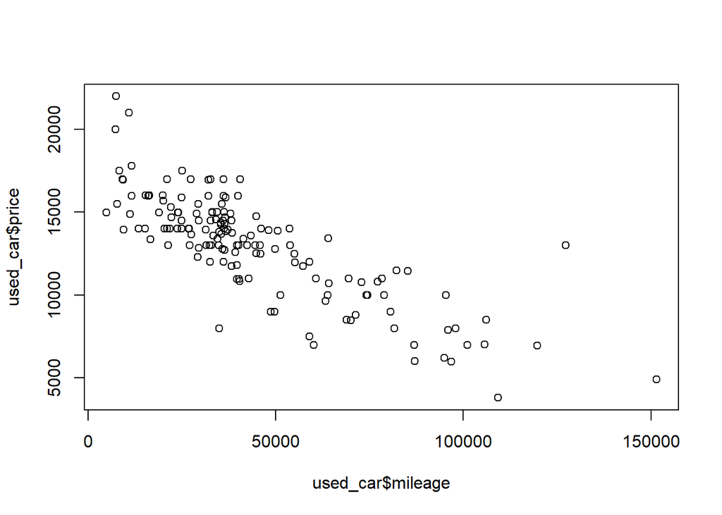

```r
plot(used_car$mileage, used_car$price)
```

#### 문제235. 문제234번의 plot 그래프에 직선을 하나 그으시오

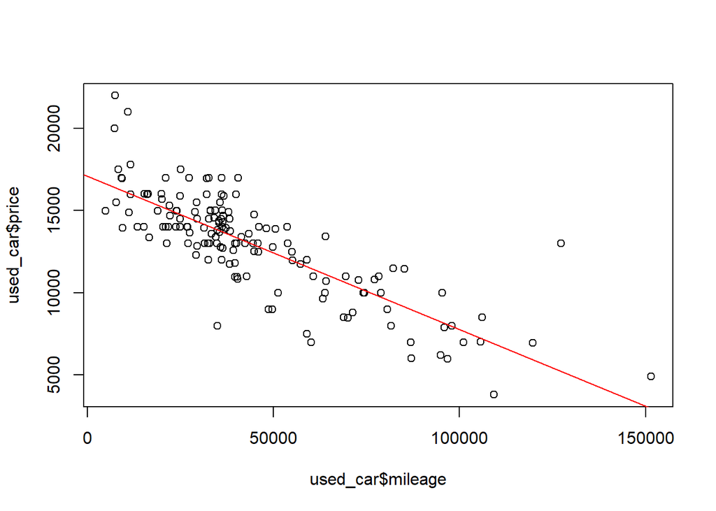

```r
model<- lm(used_car$price~used_car$mileage)

# model

plot(used_car$mileage, used_car$price)

abline(model,col='red')
```

#### 문제236. 산포도 그래프와 평균 회귀직선을 그리는 함수를 생성하시오

```r
plot_regression <- function(){
  table_name <- readline(prompt = "산포도 그래프를 그릴 테이블 명을 입력하세요 ")
  table <- get(table_name)
  x_axis <- menu(colnames(table), title = "x 축 데이터를 입력하세요 ")
  y_axis <- menu(colnames(table), title = "y 축 데이터를 입력하세요 ")

  plot(table[,x_axis], table[,y_axis], main = paste(table_name, "산포도그래프"), xlab = colnames(table[x_axis]), ylab = colnames(table[y_axis]))
  model<- lm(table[,y_axis]~table[,x_axis])
  abline(model,col='red')
}
```

#### 문제237. 오늘 만든 3개의 함수를 그래프 자동화 스크르트에 추가하시오

```r
graph_func <- function() {

    ########### 1. 패키지 설치
# 현재 컴퓨터에 필요한 패키지 설치
# 만약 패키지가 존재하지 않는 경우에만 설치

  packages <- c("XML","stringr","rJava","KoNLP","wordcloud","lubridate","data.table")

  if (length(setdiff(packages, rownames(installed.packages()))) > 0) {
    install.packages(setdiff(packages, rownames(installed.packages())))
  }

  library(data.table)
  x3 <- menu( c("막대그래프", "원형그래프", "산포도 그래프", "워드 클라우드", "사분위수 그래프",
                "산포도 그래프 & 평균 회귀직선", "히스토그램&정규분포 그래프", "분산시각화"),
                title ='원하는 그래프를 선택하세요 ')

  switch(x3,
        barchart={
          table <- get(readline(prompt = "테이블을 입력하세요~ "))
          x  <- menu( colnames(table) , title ='sum할 컬럼명(number)을 입력하세요 ')
          x1 <- menu( colnames(table) , title ='기준이될 컬럼명을 입력하세요 ')
          x2 <- menu( colnames(table) , title ='그루핑할 컬럼을 입력하세요 ')
          y <- tapply(table[, x], list(table[,x2], table[,x1]), sum)
          y[is.na(y)] <- 0

          barplot(y, col = rainbow(length(y)), beside = T)
          legend("topright", fill = rainbow(14), legend = rownames(y))

        },
        piechart={
          table <- get(readline(prompt = "테이블을 입력하세요~ "))
          x  <- menu( colnames(table) , title ='sum할 컬럼명(number)을 입력하세요 ')
          x1 <- menu( colnames(table) , title ='기준이될 컬럼명을 입력하세요 ')

          z <- tapply(table[,x], table[,x1], sum)

          rate <- round( z / sum(table[,x]) * 100, 1)
          pie(z, col= rainbow(length(names(z))), main = "Salary Pie Chart",
              labels = paste(names(z), rate,'%'))

        },
        plot = {
          table <- get(readline(prompt = "테이블을 입력하세요~ "))
          x1 <- menu(colnames(table) , title ='x축이될 컬럼명을 입력하세요 ')
          x2 <- menu(colnames(table) , title ='y축이될 컬럼명을 입력하세요 ')

          plot(table[,x1], table[,x2], xlab = colnames(table[x1]),
                     ylab = colnames(table[x2]), pch = '★', col ='Violet')
        },
        wordcloud = {
          text <- readline(prompt = "text파일명을 입력하시오 ")
          file <- readLines(paste('C:/data/',text,'.txt',sep=""))

          library(KoNLP)
          library(wordcloud)
          library(plyr)

          useSejongDic()
          nouns <- sapply(file, extractNoun, USE.NAMES = F)

          nouns <- unlist(nouns)
          # data 형식을 vector로 바꿈

          nouns <- nouns[nchar(nouns)>= 2]

          cnouns <- count(nouns)

          pal <- brewer.pal(6,"Dark2")

          pal <- pal[-(1)]

          x11()

          wordcloud(words=cnouns$x, freq=cnouns$freq, colors=pal, min.freq=5,
                    random.order=F)
        },
        boxplot = {
          table <- get(readline(prompt = "테이블명을 입력하세요~ "))
          x  <- menu( colnames(table) , title ='컬럼명을 입력하세요 ')

          boxplot(table[,x], horizontal = T)
        },
        plot2 = {
          table_name <- readline(prompt = "산포도 그래프를 그릴 테이블 명을 입력하세요 ")
          table <- get(table_name)
          x_axis <- menu(colnames(table), title = "x 축 데이터를 입력하세요 ")
          y_axis <- menu(colnames(table), title = "y 축 데이터를 입력하세요 ")

          plot(table[,x_axis], table[,y_axis], main = paste(table_name, "산포도그래프"),
                xlab = colnames(table[x_axis]), ylab = colnames(table[y_axis]))
          model<- lm(table[,y_axis]~table[,x_axis])
          abline(model,col='red')
        },
        hist = {
          table <- get(readline(prompt = "정규분포 곡선을 그릴 테이블 명을 입력하세요 "))
          col <- menu(colnames(table), title = "정규분포곡선을 그릴 컬럼명을 입력하세요 ")

          col <- table[order(table[col], decreasing = F), col]

          hist(col, col = topo.colors(8, alpha=0.7),ann = FALSE)
          par(new = T)
          plot(col, dnorm(col, mean = mean(col), sd = sd(col)), type = "l",
               main = paste(round(skewness(col),3),"정규분포 그래프"),ylab = "도수",
               axes = FALSE)
        },
        var = {
            table <- get(readline(prompt = "분산을 시각화할 테이블명을 입력하시오 "))
            col <- menu(colnames(table), title = '분산을 시각화할 컬럼을 선택하세요.')
            x <- table[,col]
            cnt <- length(x)
            plot( x, main = paste("분산 =", round(var(x),3), "표준편차 =", round(sd(x),3)),
                  col = "Navy Blue",ylab = colnames(table[col]))
            lines(rep(mean(x),cnt), type = "l", col = "Violet Red")
        }

  )

}
```

### 2_10. 이원교차표

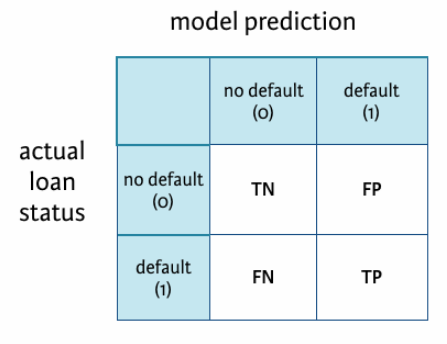

> 참 긍정(TP, true positive) 관심범주를 정확이 분류  
> 참 부정(TN, true Negative) 관심 범주가 아닌 것을 정확하게 분류

> 거짓 긍정(FP, False Positive) 관심 범주로 잘못 분류  
> 거짓 부정(FN, False Negative) 관심 범주가 아닌 것으로 잘못 분류

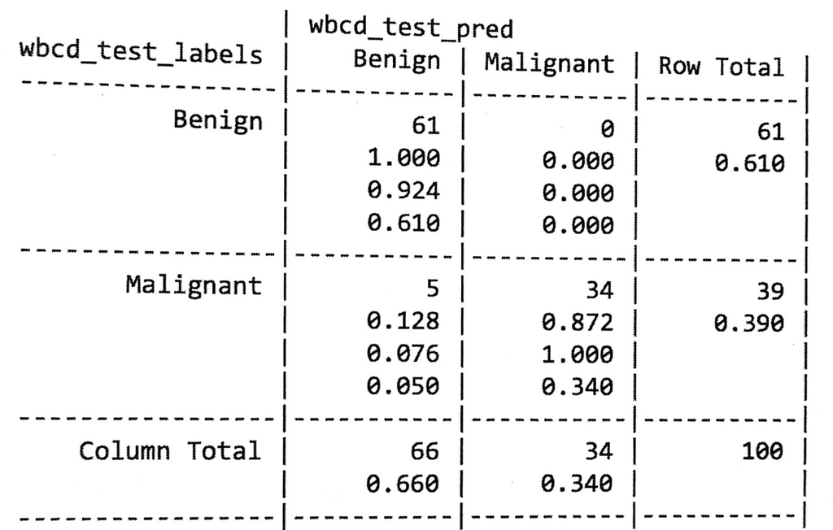

#### 문제238. 직업(세로), 부서번호(가로), 직업별 부서번호별 인원수를 출력하시오

```r
# aggregate(empno~job,emp,length)
#
tapply(emp$empno,list(emp$deptno,emp$job),length,default = 0)
```

```
##    ANALYST CLERK MANAGER PRESIDENT SALESMAN
## 10       0     1       1         1        0
## 20       2     2       1         0        0
## 30       0     1       1         0        4
```

```r
table(emp$deptno, emp$job)
```

```
##
##      ANALYST CLERK MANAGER PRESIDENT SALESMAN
##   10       0     1       1         1        0
##   20       2     2       1         0        0
##   30       0     1       1         0        4
```

#### 문제239. 이원교차표를 출력하는 CrossTable 함수를 이용해서 위의 결과를 출력하시오

```r
# (그냥 이원교차표 어떻게 생긴지만 봄)
# 이원교차표는 머신러닝 학습 알고리즘의 정확도를 확인하고 제대로 데이터를 분류하는 머신러닝인지를 확인하고자할 때 사용하는 툴

# install.packages("gmodels")
library(gmodels)
CrossTable(x = emp$deptno, y = emp$job)
```

```
##
##
##    Cell Contents
## |-------------------------|
## |                       N |
## | Chi-square contribution |
## |           N / Row Total |
## |           N / Col Total |
## |         N / Table Total |
## |-------------------------|
##
##
## Total Observations in Table:  14
##
##
##              | emp$job
##   emp$deptno |   ANALYST |     CLERK |   MANAGER | PRESIDENT |  SALESMAN | Row Total |
## -------------|-----------|-----------|-----------|-----------|-----------|-----------|
##           10 |         0 |         1 |         1 |         1 |         0 |         3 |
##              |     0.429 |     0.024 |     0.198 |     2.881 |     0.857 |           |
##              |     0.000 |     0.333 |     0.333 |     0.333 |     0.000 |     0.214 |
##              |     0.000 |     0.250 |     0.333 |     1.000 |     0.000 |           |
##              |     0.000 |     0.071 |     0.071 |     0.071 |     0.000 |           |
## -------------|-----------|-----------|-----------|-----------|-----------|-----------|
##           20 |         2 |         2 |         1 |         0 |         0 |         5 |
##              |     2.314 |     0.229 |     0.005 |     0.357 |     1.429 |           |
##              |     0.400 |     0.400 |     0.200 |     0.000 |     0.000 |     0.357 |
##              |     1.000 |     0.500 |     0.333 |     0.000 |     0.000 |           |
##              |     0.143 |     0.143 |     0.071 |     0.000 |     0.000 |           |
## -------------|-----------|-----------|-----------|-----------|-----------|-----------|
##           30 |         0 |         1 |         1 |         0 |         4 |         6 |
##              |     0.857 |     0.298 |     0.063 |     0.429 |     3.048 |           |
##              |     0.000 |     0.167 |     0.167 |     0.000 |     0.667 |     0.429 |
##              |     0.000 |     0.250 |     0.333 |     0.000 |     1.000 |           |
##              |     0.000 |     0.071 |     0.071 |     0.000 |     0.286 |           |
## -------------|-----------|-----------|-----------|-----------|-----------|-----------|
## Column Total |         2 |         4 |         3 |         1 |         4 |        14 |
##              |     0.143 |     0.286 |     0.214 |     0.071 |     0.286 |           |
## -------------|-----------|-----------|-----------|-----------|-----------|-----------|
##
##
```

#### 문제240. 직업별로 월급의 차이가 존쟇는지 이원교차표로 확인하시오!

#### 월급이 2500을 기준으로 직업별로 각각 월급이 2500 이상인 사원과 2500보다 작은 사원들이 어떻게 분포되어 있는지 확인하시오.

##### 실제, 예측

```r
# True/False확인
library(data.table)
data.table(emp$sal, emp$sal >= 2500)
```

```
##       V1    V2
##  1: 5000  TRUE
##  2: 2850  TRUE
##  3: 2450 FALSE
##  4: 2975  TRUE
##  5: 1250 FALSE
##  6: 1600 FALSE
##  7: 1500 FALSE
##  8:  950 FALSE
##  9: 1250 FALSE
## 10: 3000  TRUE
## 11:  800 FALSE
## 12: 3000  TRUE
## 13: 1100 FALSE
## 14: 1300 FALSE
```

```r
# CrossTable(x = emp$job, y = ifelse(emp$sal>=2500,TRUE,FALSE))
CrossTable(emp$job, emp$sal >= 2500)
```

```
##
##
##    Cell Contents
## |-------------------------|
## |                       N |
## | Chi-square contribution |
## |           N / Row Total |
## |           N / Col Total |
## |         N / Table Total |
## |-------------------------|
##
##
## Total Observations in Table:  14
##
##
##              | emp$sal >= 2500
##      emp$job |     FALSE |      TRUE | Row Total |
## -------------|-----------|-----------|-----------|
##      ANALYST |         0 |         2 |         2 |
##              |     1.286 |     2.314 |           |
##              |     0.000 |     1.000 |     0.143 |
##              |     0.000 |     0.400 |           |
##              |     0.000 |     0.143 |           |
## -------------|-----------|-----------|-----------|
##        CLERK |         4 |         0 |         4 |
##              |     0.794 |     1.429 |           |
##              |     1.000 |     0.000 |     0.286 |
##              |     0.444 |     0.000 |           |
##              |     0.286 |     0.000 |           |
## -------------|-----------|-----------|-----------|
##      MANAGER |         1 |         2 |         3 |
##              |     0.447 |     0.805 |           |
##              |     0.333 |     0.667 |     0.214 |
##              |     0.111 |     0.400 |           |
##              |     0.071 |     0.143 |           |
## -------------|-----------|-----------|-----------|
##    PRESIDENT |         0 |         1 |         1 |
##              |     0.643 |     1.157 |           |
##              |     0.000 |     1.000 |     0.071 |
##              |     0.000 |     0.200 |           |
##              |     0.000 |     0.071 |           |
## -------------|-----------|-----------|-----------|
##     SALESMAN |         4 |         0 |         4 |
##              |     0.794 |     1.429 |           |
##              |     1.000 |     0.000 |     0.286 |
##              |     0.444 |     0.000 |           |
##              |     0.286 |     0.000 |           |
## -------------|-----------|-----------|-----------|
## Column Total |         9 |         5 |        14 |
##              |     0.643 |     0.357 |           |
## -------------|-----------|-----------|-----------|
##
##
```

#### 문제241. 중고차의 모델의 종류가 어떻게 되는지 출력하시오

```r
unique(used_car$model)
```

```
## [1] SEL SE  SES
## Levels: SE SEL SES
```

#### 문제242. 차 모델별로 보수적인 색을 가진 자동차의 비율을 비교해보기위해서 이원교차표를 살펴보시오

보수적인 색깔: Black, Gray, Silver, White

```r
CrossTable(used_car$model, used_car$color %in% c('Black', 'Gray', 'Silver', 'White'))
```

```
##
##
##    Cell Contents
## |-------------------------|
## |                       N |
## | Chi-square contribution |
## |           N / Row Total |
## |           N / Col Total |
## |         N / Table Total |
## |-------------------------|
##
##
## Total Observations in Table:  150
##
##
##                | used_car$color %in% c("Black", "Gray", "Silver", "White")
## used_car$model |     FALSE |      TRUE | Row Total |
## ---------------|-----------|-----------|-----------|
##             SE |        27 |        51 |        78 |
##                |     0.009 |     0.004 |           |
##                |     0.346 |     0.654 |     0.520 |
##                |     0.529 |     0.515 |           |
##                |     0.180 |     0.340 |           |
## ---------------|-----------|-----------|-----------|
##            SEL |         7 |        16 |        23 |
##                |     0.086 |     0.044 |           |
##                |     0.304 |     0.696 |     0.153 |
##                |     0.137 |     0.162 |           |
##                |     0.047 |     0.107 |           |
## ---------------|-----------|-----------|-----------|
##            SES |        17 |        32 |        49 |
##                |     0.007 |     0.004 |           |
##                |     0.347 |     0.653 |     0.327 |
##                |     0.333 |     0.323 |           |
##                |     0.113 |     0.213 |           |
## ---------------|-----------|-----------|-----------|
##   Column Total |        51 |        99 |       150 |
##                |     0.340 |     0.660 |           |
## ---------------|-----------|-----------|-----------|
##
##
```